# umap

## Individual gene evaluation

The evaluation above was to test independence between shape/movement and overall gene expression.

上述の処理は、形動きとトランスクリプトーム全体とを比較し、その間に総体として関連があることを示したものであった。

The followings calculate correlation coefficient between the knn-graph of shape/movement and individual gene's expression values.

以下で行っているのは、個々の遺伝子ごとに、その発現量が、形動きと関連しているか。

When number of genes is one, knn-graph should be a straight line. Therefore, the correlation coefficient of distance matrices is calculated with the same way with UMAP vs. UMAP.

計算の実態としては、全遺伝子でUMAPを行ってknnグラフを作ってその距離行列を作るのと、同じやり方が使える。１遺伝子の発現量は１次元空間上の点となるので、一直線グラフ上にすべての細胞が配置され、その一直線グラフ上の距離を測ることは、その遺伝子の発現量の差を求めることに他ならないからである。

No p-value is calculated but only correlation coefficient values are calculated.

p値は算出せず、相関係数のみを出している。

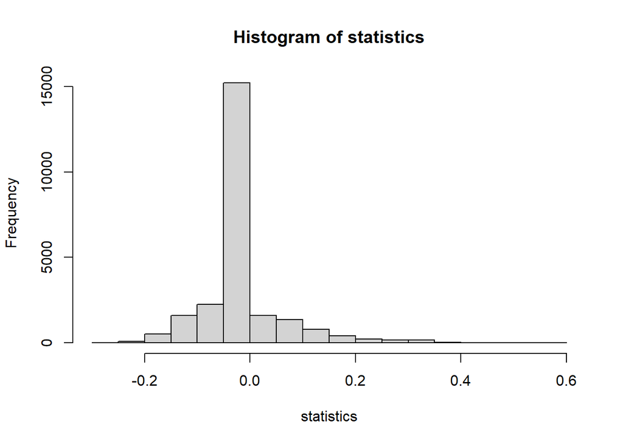

```r
hist(statistics)
```

```r
gene.id <- d_y[,1]
```

```r
corr.order <- order(statistics,decreasing=TRUE)
```

```r
gene.id.sorted <- gene.id[corr.order]
correlation.coef.sorted <- statistics[corr.order]

ret <- data.frame(gene.id=gene.id.sorted,corr.coef=correlation.coef.sorted)

write.table(ret,file="out.txt",sep="\t")
```

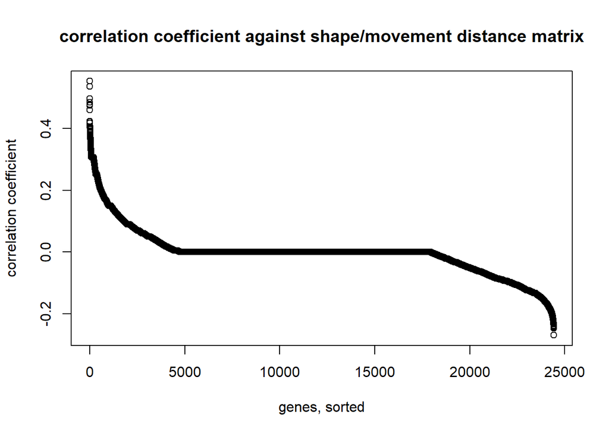

```r
plot(correlation.coef.sorted,main="correlation coefficient against shape/movement distance matrix",xlab="genes, sorted", ylab="correlation coefficient")
```

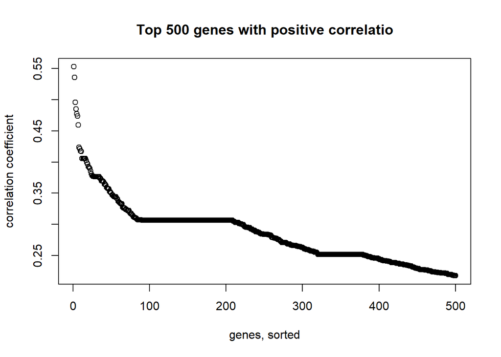

```r
plot(correlation.coef.sorted[1:500],main="Top 500 genes with positive correlatio",xlab="genes, sorted", ylab="correlation coefficient")
```